# Factors contributing to Loan Pricing on Prosper App

## by Ifeoluwa Atunde

## Introduction

> Prosper is a leading financial peer-to-peer lending company that provides a platform where borrowers and lenders interact. The peer-to-peer lending platform market has been booming recently.Through these platforms, hundreds of investors earn, while thousands of borrowers receive funding more quickly.Although these platforms offer credit scores and basic borrower information to ensure that tradings are conducted in a secure atmosphere, there are still thousands of consumers who run the risk of losing money.

## Dataset Overview

> Dataset has 81 columns which is too large for our analysis, we need to create a new dataframe to wearhouse columns that will be important to this particular analysis. Access data in each column and identify elements that need to be fixed, in order to create interesting and trustworthy analyses and visualizations.

```
(113937, 81)
```

|  | ListingKey | ListingNumber | ListingCreationDate | CreditGrade | Term | LoanStatus | ClosedDate | BorrowerAPR | BorrowerRate | LenderYield | ... | LP_ServiceFees | LP_CollectionFees | LP_GrossPrincipalLoss | LP_NetPrincipalLoss | LP_NonPrincipalRecoverypayments | PercentFunded | Recommendations | InvestmentFromFriendsCount | InvestmentFromFriendsAmount | Investors |
| --- | --- | --- | --- | --- | --- | --- | --- | --- | --- | --- | --- | --- | --- | --- | --- | --- | --- | --- | --- | --- | --- |
| 0 | 1021339766868145413AB3B | 193129 | 2007-08-26 19:09:29.263000000 | C | 36 | Completed | 2009-08-14 00:00:00 | 0.16516 | 0.1580 | 0.1380 | ... | -133.18 | 0.0 | 0.0 | 0.0 | 0.0 | 1.0 | 0 | 0 | 0.0 | 258 |
| 1 | 10273602499503308B223C1 | 1209647 | 2014-02-27 08:28:07.900000000 | NaN | 36 | Current | NaN | 0.12016 | 0.0920 | 0.0820 | ... | 0.00 | 0.0 | 0.0 | 0.0 | 0.0 | 1.0 | 0 | 0 | 0.0 | 1 |
| 2 | 0EE9337825851032864889A | 81716 | 2007-01-05 15:00:47.090000000 | HR | 36 | Completed | 2009-12-17 00:00:00 | 0.28269 | 0.2750 | 0.2400 | ... | -24.20 | 0.0 | 0.0 | 0.0 | 0.0 | 1.0 | 0 | 0 | 0.0 | 41 |
| 3 | 0EF5356002482715299901A | 658116 | 2012-10-22 11:02:35.010000000 | NaN | 36 | Current | NaN | 0.12528 | 0.0974 | 0.0874 | ... | -108.01 | 0.0 | 0.0 | 0.0 | 0.0 | 1.0 | 0 | 0 | 0.0 | 158 |
| 4 | 0F023589499656230C5E3E2 | 909464 | 2013-09-14 18:38:39.097000000 | NaN | 36 | Current | NaN | 0.24614 | 0.2085 | 0.1985 | ... | -60.27 | 0.0 | 0.0 | 0.0 | 0.0 | 1.0 | 0 | 0 | 0.0 | 20 |

5 rows × 81 columns

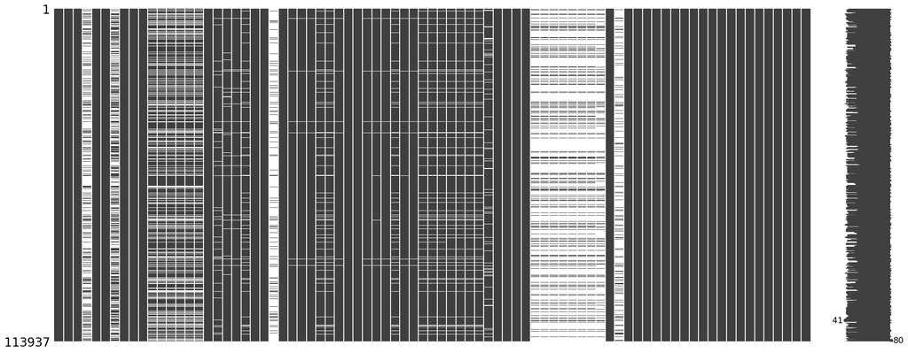

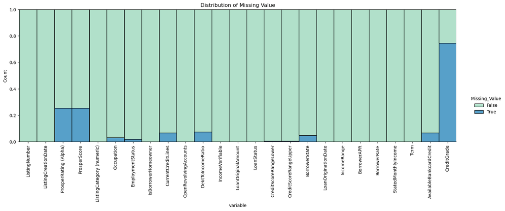

It is observed that credit grade has the highest count of missing data followed by ProsperRating (Alpha) and ProsperScore as well as debt to income ratio. For the numeric data type we replace missing values with its mean while for strings we replace with NAN

# ProsperRating (Alpha)

> Prosper Rating ranges from HR to AA(high to low risk) with a large porportion of rating missing as proper relied soly on rating from independent rating agencies prior to July 2009. from the diagram above it is observe that category c has the highest amount of loan disbursement. this is inline with reality as category is medium risk and most investors are speculators.

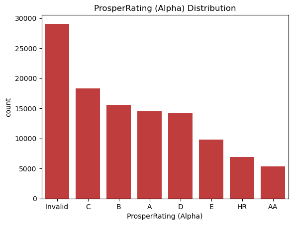

# Loan Status

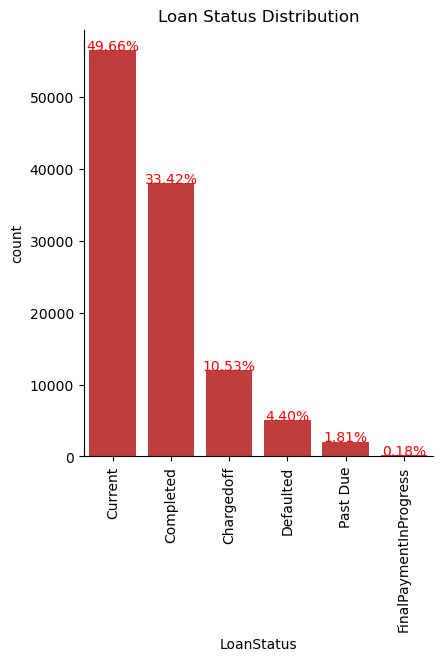

## Loan book Size

> Prior to 2009, Credit Grade, a key indicator of credit risk for investors, was used. It was based on the borrower's credit score as reported by an impartial credit reporting bureau. However, at the time, Prosper's lending performance was not very good. Prosper established a new credit risk gauge, the Prosper Rating, which was viewed as harsher credit criteria for borrowers, after being temporarily shut down on the request of the SEC and restructuring. Prosper's loan default rate has dramatically decreased, according to the new loan performance. This is evident from the increase in prosper loan from 25.5% before 2009 to about 74.5% there after.

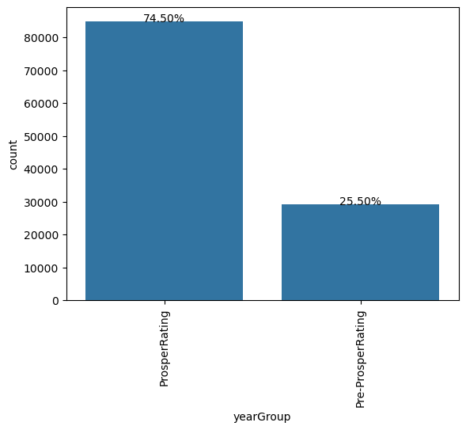

## Loan Tenor

> A loan could last anywhere between one year and five years. The most prevalent kind is a 3-year (medium term) loan, followed by a 5-year loan. Short-term loans are rather rare.

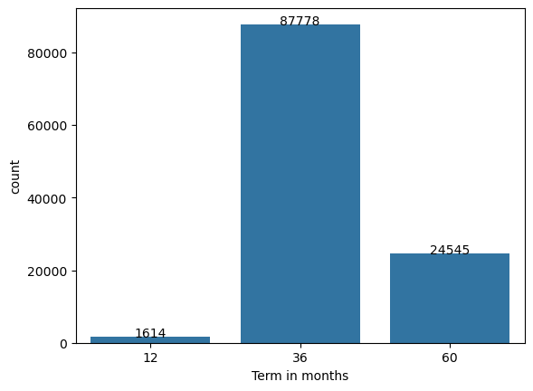

## Wage Group

The majority of borrowers are from the middle class, with monthly salaries averaging between $2500 and $6000.

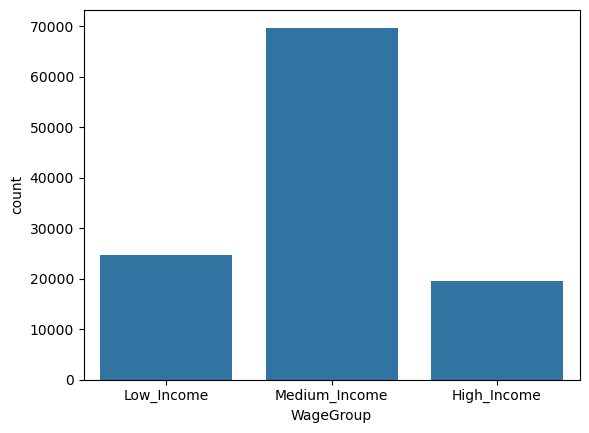

### Relationship between Prosper and Credit score pre-2009 and post.

It is observed from the visuals that the implementation of Propser's internal rating system, which is stricter than ratings provided by independent rating organizations, resulted in significant decline in default rates. It is safe to state that Prosper's risk management tactics have greatly improved as a result of this internal evaluation.

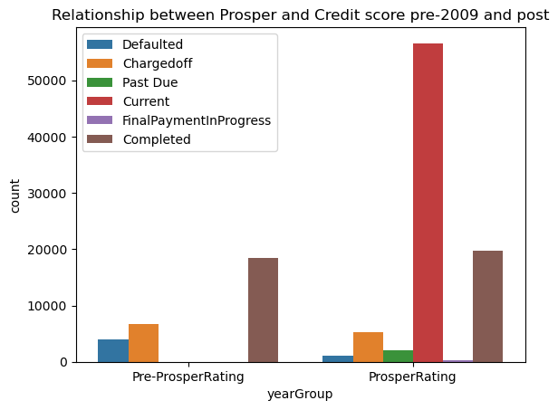

## What's relationship between CreditGrade/ProsperRating(s) and ProsperScore to Loan Tenor?

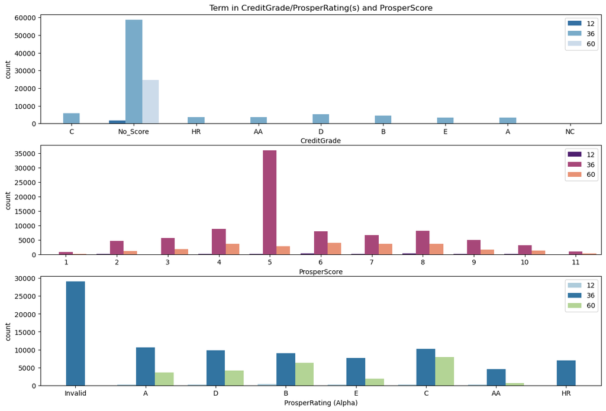

## Relationship Between ProsperScore,BorrowerRate and categorical Variables

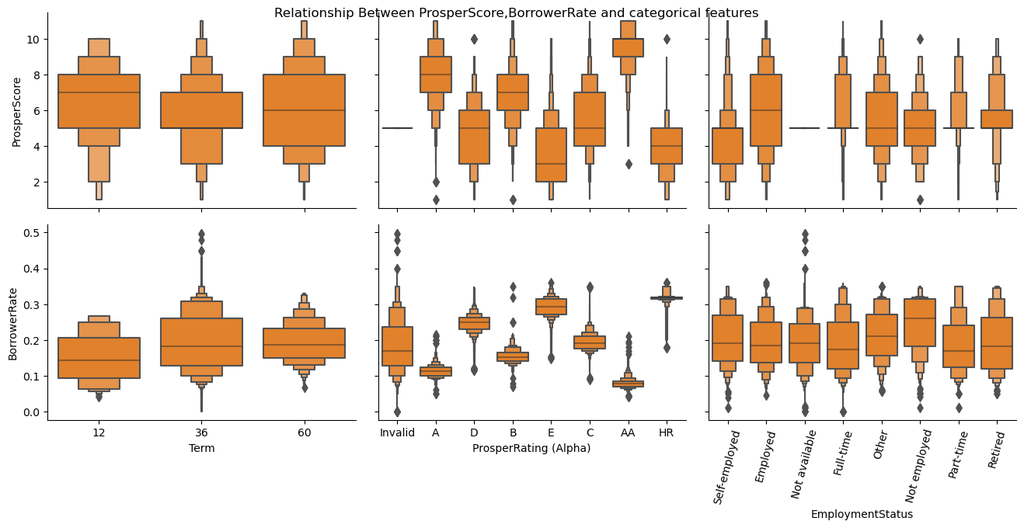

When comparing the distributions of the different credit risks and the borrower rate using boxen plots, it is evident that a higher (better) score is negatively connected with a lower interest rate. This argument is best illustrated by the data for the ProsperRating (Alpha) variable, where the decline is more pronounced.

## Prosper Rating VS Credit Score Average

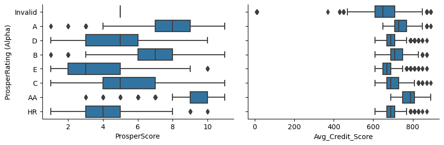

> The graphs above demonstrate that there are modest positive trends between Prosper Rating and Prosper Score, and that the volatility of Prosper Score within each Prosper Rating is more concentrated. In each Prosper Rating, the volatility of the Credit Score Average is somewhat greater than the Prosper Score's.

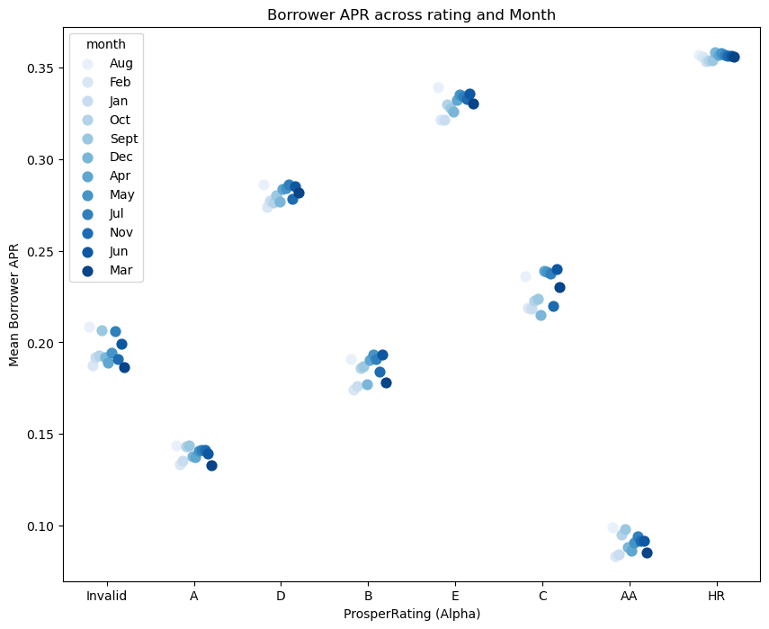

## Does Prosper consider Collateral(Home Ownership) in assigning rating and disbursement of loans?

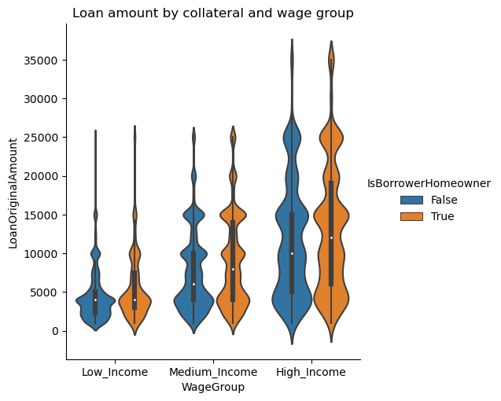

The graph above explains how high income borrowers with collateral are more likely to receive loans with higher amounts from Prosper. The best risk management techniques are surely followed in this situation.

# Relationship Between Loan Status, ProsperScore and ProsperRating.

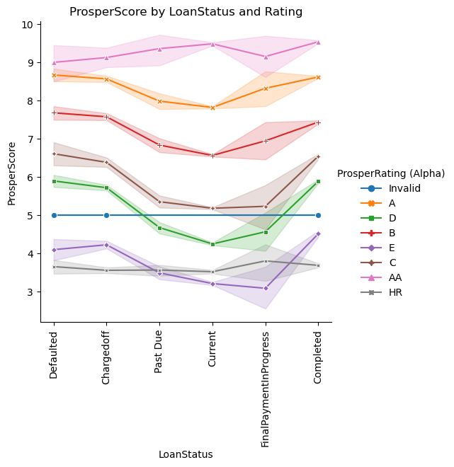

This demonstrates that current loans with a rating of 9 are classified as AA by Prosper. This demonstrates that only high quality loans with little risk are given to borrowers in accordance with Prosper's risk management techniques. Investors' trust in Prosper as a platform where risk and return are balanced will increase as a result of this strategy.

# Thank you for your attention

[output not shown]

[output cut: 126 more lines]

[output not shown]